# Statistical Learning and Data Mining (QBUS6810)

## Tutorial 7: Variable Selection and Regularization in Linear Regression

In this tutorial we will study how to implement variable selection and regularisation methods for linear regression in Python. Some of the code required is in the `statlearning.py` module, which you should have in the same folder as the one from which you are running Jupyter.

House Pricing Data  
Exploratory Data Analysis  
Response Transformation  
OLS  
Subset Selection  
Scaling the Predictors  
Ridge Regression  
Lasso  
Elastic Net  
Model Evaluation

This notebook relies on the following libraries and settings.

```python
# Packages
import numpy as np
from scipy import stats
import pandas as pd
import matplotlib.pyplot as plt
import seaborn as sns
import warnings
warnings.filterwarnings('ignore')
```

```python
# Plot settings
sns.set_context('notebook')
sns.set_style('ticks')
colours = ['#1F77B4', '#FF7F0E', '#2CA02C', '#DB2728', '#9467BD', '#8C564B', '#E377C2','#7F7F7F', '#BCBD22', '#17BECF']
crayon = ['#4E79A7','#F28E2C','#E15759','#76B7B2','#59A14F', '#EDC949','#AF7AA1','#FF9DA7','#9C755F','#BAB0AB']
sns.set_palette(colours)
%matplotlib inline
plt.rcParams['figure.figsize'] = (9, 6)
```

```python
# Model selection and evaluation tools
from sklearn.model_selection import train_test_split
from sklearn.model_selection import RandomizedSearchCV
from sklearn.metrics import mean_squared_error, r2_score
```

## House Pricing Data

We will use the data from [De Cock (2011)](http://www.tandfonline.com/doi/abs/10.1080/10691898.2011.11889627), who compiled a detailed dataset of residential property sales in a North American city. It is used in one of the most popular practice [Kaggle competitions](https://www.kaggle.com/c/house-prices-advanced-regression-techniques). This dataset is characterised by a large number of predictor variables (81, including categorical, discrete, and continuous variables). See the [documentation](https://ww2.amstat.org/publications/jse/v19n3/Decock/DataDocumentation.txt) for a description of the original variables.

The original dataset has been cleaned and processed into a version that is ready for analysis. After coding the categorical predictors using dummy variables and creating some other relevant variables, the processed dataset has 195 predictors. The processsed dataset is posted on Canvas.

```python
data=pd.read_csv('Datasets/AmesHousing-Processed.csv')
data.head()
```

|  | 1stFlrSF | 2ndFlrSF | 3SsnPorch | Age | BsmtFinSF1 | BsmtFinSF2 | BsmtUnfSF | EnclosedPorch | GarageArea | LotArea | ... | RoofMatl_Other | RoofStyle_Hip | RoofStyle_Other | ScreenPorchZero | WoodDeckSFZero | YrSold_2007 | YrSold_2008 | YrSold_2009 | YrSold_2010 | SalePrice |
| --- | --- | --- | --- | --- | --- | --- | --- | --- | --- | --- | --- | --- | --- | --- | --- | --- | --- | --- | --- | --- | --- |
| 0 | 1656 | 0 | 0 | 50 | 639.0 | 0.0 | 441.0 | 0 | 528.0 | 31770 | ... | 0 | 1 | 0 | 1 | 0 | 0 | 0 | 0 | 1 | 215000 |
| 1 | 896 | 0 | 0 | 49 | 468.0 | 144.0 | 270.0 | 0 | 730.0 | 11622 | ... | 0 | 0 | 0 | 0 | 0 | 0 | 0 | 0 | 1 | 105000 |
| 2 | 1329 | 0 | 0 | 52 | 923.0 | 0.0 | 406.0 | 0 | 312.0 | 14267 | ... | 0 | 1 | 0 | 1 | 0 | 0 | 0 | 0 | 1 | 172000 |
| 3 | 2110 | 0 | 0 | 42 | 1065.0 | 0.0 | 1045.0 | 0 | 522.0 | 11160 | ... | 0 | 1 | 0 | 1 | 1 | 0 | 0 | 0 | 1 | 244000 |
| 4 | 928 | 701 | 0 | 13 | 791.0 | 0.0 | 137.0 | 0 | 482.0 | 13830 | ... | 0 | 0 | 0 | 1 | 0 | 0 | 0 | 0 | 1 | 189900 |

5 rows × 196 columns

We split the data into training and test sets. Here we use a smaller training dataset (20%) in order to better illustrate the advantages of regularisation.

```python
response='SalePrice'
predictors=list(data.columns.values[:-1])

# Randomly split indexes
index_train, index_test  = train_test_split(np.array(data.index), train_size=0.2, random_state=5)

# Write training and test sets
train = data.loc[index_train,:].copy()
test =  data.loc[index_test,:].copy()

y_train = train[response]
y_test = test[response]

X_train = train[predictors].copy()
X_test = test[predictors].copy()
```

## Exploratory Data Analysis

One can gain some insight on the distribution of the response by plotting a histogram. The response variable is right-skewed, hence we need to apply an appropriate transformation to reduce its skewness.

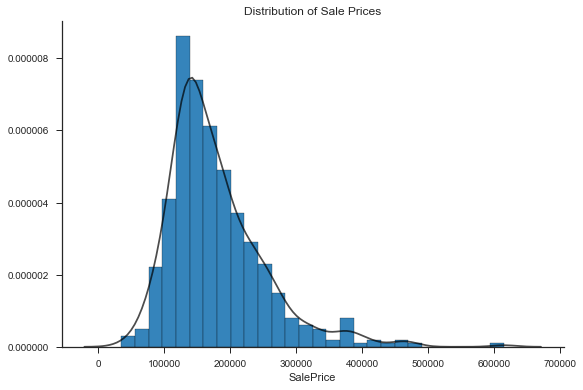

```python
from statlearning import plot_histogram

plot_histogram(y_train)
plt.title('Distribution of Sale Prices')
plt.show()
```

Many of the numerical variables have a substantial number of zeros, since they refer to variables that do not apply to all houses (such as the second floor area). The dataset includes additional constructed dummy variables (such as `2ndFlrSFZero`, the indicator of whether the second floor area is zero) to account for this feature of the data.

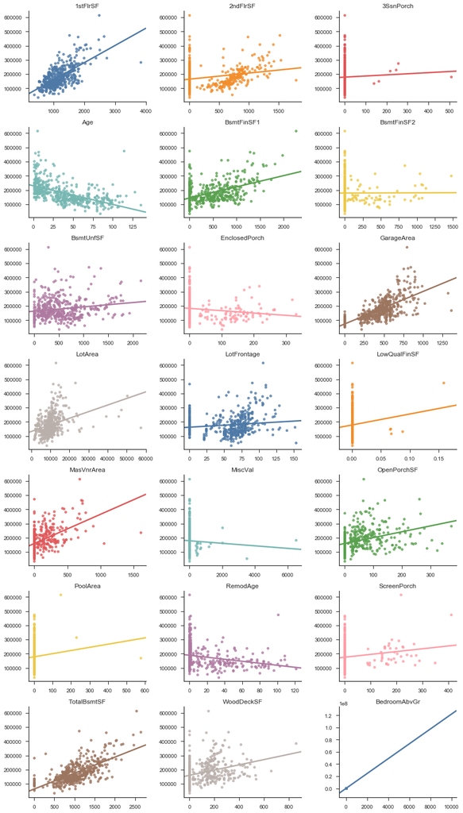

```python
from statlearning import plot_regressions

with sns.color_palette(crayon):
    plot_regressions(X_train.iloc[:,:21], y_train)
    plt.show()
```

## Response Transformation

The above histogram and scatterplots suggest that (i) the response variable is right skewed (ii) there are nonlinear relationships between the response and certain predictors (iii) the noise has non-constant variance as a function of the predictors.

It is very common to observe these three patterns together in economic data, for reasons such as diminishing returns (additional space becomes less valuable if you have more space to begin with) and inflation (prices, salaries, etc, increase in percentage terms, not in a linear fashion).

In this situation, transforming the response will typically improve performance, as it is a parsimonious way to account for nonlinearities, reduce skewness, and make the noise variance near constant. The log transformation is the most common transformation of this type.

```python
y_train = np.log(train[response])
y_test = np.log(test[response])
```

Compare the univariate plots below with the original ones.

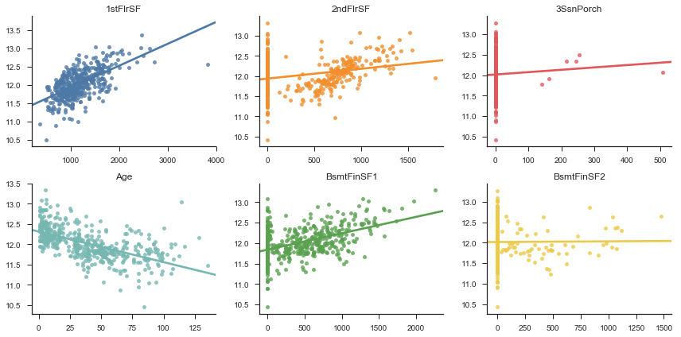

```python
from statlearning import plot_regressions

with sns.color_palette(crayon):
    plot_regressions(X_train.iloc[:,:6], y_train)
    plt.show()
```

## OLS

As before, we will use the Scikit-Learn [`LinearRegression`](http://scikit-learn.org/stable/modules/generated/sklearn.linear_model.LinearRegression.html#sklearn.linear_model.LinearRegression) method to fit the OLS.

Note that, unlike the regularised methods that we use later on in this tutorial, we do not generally need to standardise the data for fitting the OLS. We will use the original non-standardised training data for OLS and Forward selection (next section).

```python
from sklearn.linear_model import LinearRegression

ols = LinearRegression()
ols.fit(X_train, y_train)
```

```
LinearRegression(copy_X=True, fit_intercept=True, n_jobs=1, normalize=False)
```

## Subset Selection

Even though Scikit-Learn has functionality for subset selection, its methods are not exactly the same as the methods that we have seen in the lecture. Therefore, we will use the subset selection code written separately in the statistical learning module `statlearning.py`, which has been posted on Canvas. In this tutorial we will use forward selection.

Below, we also add a `%%time` command to measure how long the cell takes to run. Note that due to the many iterations involved in subset selection, fitting these algorithms can take some time.

```python
%%time
from statlearning import forward

fwd = forward()
fwd.fit(X_train, y_train)
```

```
Wall time: 48.5 s
```

## Scaling the Predictors

It is essential to scale the predictors before fitting regularised linear methods. Like several other machine learning algorithms, regularised linear methods do not perform well when predictors have very different scales (because the penalty term in the objective function treats all coefficients as comparable).

The most common type of scaling is standardisation, where we transform each predictor by subtracting its sample average and diving the result by its standard deviation. The Scikit-Learn [`StandardScaler`](http://scikit-learn.org/stable/modules/generated/sklearn.preprocessing.StandardScaler.html) method makes it easy to process the data in this way.

We have two ways of implementing a workflow that includes scaling. The first is to use the standard scaler to preprocess the predictor matrix, and then work with the transformed data as usual. The second option is to use a Scikit-Learn [pipeline](http://scikit-learn.org/stable/modules/generated/sklearn.pipeline.Pipeline.html#sklearn.pipeline.Pipeline), which allows the user to combine transformations with a final estimator.

We start with the first option. The means and standard deviations used for standardizing are computed on the training data.

```python
from sklearn.preprocessing import StandardScaler

scaler = StandardScaler()
scaler.fit(X_train)

X_train_scaled = scaler.transform(X_train)
X_test_scaled = scaler.transform(X_test)
```

We use a ridge regression to illustrate the process of fitting the model and computing predictions, without worrying about the details of the algorithm for now.

```python
from sklearn.linear_model import Ridge

ridge = Ridge()
ridge.fit(X_train_scaled, y_train)
y_pred = ridge.predict(X_test_scaled)
print(y_pred[0]) # we will get the result below
```

```
11.29827222406829
```

The other option is to use a Scikit-Learn pipeline, which allows the user to combine transformations with a final estimator. Note that the results are exactly the same.

```python
from sklearn.pipeline import Pipeline

ridge = Pipeline([
    ('scaler', StandardScaler()),
    ('estimator', Ridge()),
])

ridge.fit(X_train, y_train)
y_pred = ridge.predict(X_test)
print(y_pred[0])
```

```
11.29827222406829
```

## Ridge Regression

We start with the Ridge regression method. The [`RidgeCV`](http://scikit-learn.org/stable/modules/generated/sklearn.linear_model.RidgeCV.html#sklearn.linear_model.RidgeCV) function is the most convenient implementation. We need to manually specify a grid of the penalty weight values (called alphas by the package).

Below, we present the code according to the two ways of handling predictor scaling. First, using preprocessing with the standard scaler.

```python
from sklearn.linear_model import RidgeCV

alphas = list(np.logspace(-15, 15, 151, base=2))

ridge = RidgeCV(alphas=alphas, cv=5)
ridge.fit(X_train_scaled, y_train)
```

```
RidgeCV(alphas=[3.0517578125e-05, 3.505549179068098e-05, 4.026818575356734e-05, 4.625599873383782e-05, 5.313418965430448e-05, 6.103515625e-05, 7.011098358136196e-05, 8.053637150713468e-05, 9.251199746767564e-05, 0.00010626837930860896, 0.0001220703125, 0.00014022196716272393, 0.00016107274301426937,…
    cv=5, fit_intercept=True, gcv_mode=None, normalize=False, scoring=None,
    store_cv_values=False)
```

The methods applies a high degree of shrinkage, as can be seen from the following line, which computes the Ridge shrinkage factor:

```python
round(np.linalg.norm(ridge.coef_)/np.linalg.norm(np.ravel(ols.coef_)), 3)
```

```
0.034
```

Now, using a pipeline. The results are the same as when using the standard scaler.

```python
from sklearn.pipeline import Pipeline

ridge = Pipeline([
    ('scaler', StandardScaler()),
    ('estimator', RidgeCV(alphas=alphas, cv=5)),
])

ridge.fit(X_train, y_train)
```

```
Pipeline(memory=None,
     steps=[('scaler', StandardScaler(copy=True, with_mean=True, with_std=True)), ('estimator', RidgeCV(alphas=[3.0517578125e-05, 3.505549179068098e-05, 4.026818575356734e-05, 4.625599873383782e-05, 5.313418965430448e-05, 6.103515625e-05, 7.011098358136196e-05, 8.053637150713468e-05, 9.2511997467675…
    store_cv_values=False))])
```

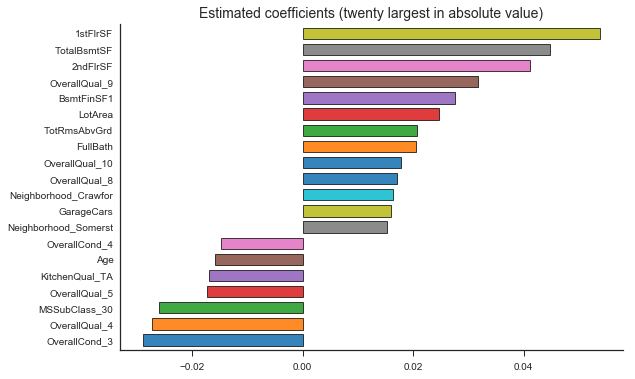

```python
from statlearning import plot_coefficients
plot_coefficients(ridge._final_estimator, predictors)
plt.show()
```

## Lasso

The process is similar for LASSO. We use the [`LassoCV`](http://scikit-learn.org/stable/modules/generated/sklearn.linear_model.LassoCV.html) class to fit and tune the lasso model. The reason for this class, as opposed to running a grid search on the [`Lasso`](http://scikit-learn.org/stable/modules/generated/sklearn.linear_model.Lasso.html) class, is that there is an efficient algorithm for computing the path of solutions as we vary the lasso penalty weight parameter. The same is true for the other models.

Again, we present the code according to the two ways of handling predictor scaling. First, using preprocessing with the standard scaler.

```python
from sklearn.linear_model import LassoCV

lasso = LassoCV(cv=5)
lasso.fit(X_train_scaled, y_train)
```

```
LassoCV(alphas=None, copy_X=True, cv=5, eps=0.001, fit_intercept=True,
    max_iter=1000, n_alphas=100, n_jobs=1, normalize=False, positive=False,
    precompute='auto', random_state=None, selection='cyclic', tol=0.0001,
    verbose=False)
```

Here is the Lasso shrinkage factor:

```python
round(np.linalg.norm(lasso.coef_, ord=1)/np.linalg.norm(np.ravel(ols.coef_),ord=1),3)
```

```
0.079
```

Now, using a pipeline.

```python
lasso = Pipeline([
    ('scaler', StandardScaler()),
    ('estimator', LassoCV(cv=5)),
])

lasso.fit(X_train, y_train)
```

```
Pipeline(memory=None,
     steps=[('scaler', StandardScaler(copy=True, with_mean=True, with_std=True)), ('estimator', LassoCV(alphas=None, copy_X=True, cv=5, eps=0.001, fit_intercept=True,
    max_iter=1000, n_alphas=100, n_jobs=1, normalize=False, positive=False,
    precompute='auto', random_state=None, selection='cyclic', tol=0.0001,
    verbose=False))])
```

The lasso shrinks 88 coefficients to zero.

```python
reg = lasso._final_estimator # the final estimator attribute refers to the pipeline
np.sum(reg.coef_==0.0)
```

```
88
```

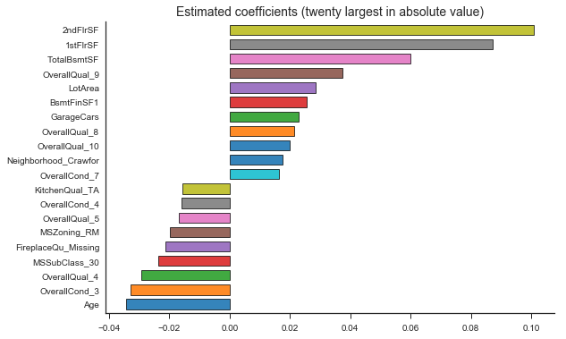

```python
from statlearning import plot_coefficients

plot_coefficients(reg, predictors)
plt.show()
```

## Elastic Net

We use the [`ElasticNetCV`](http://scikit-learn.org/stable/modules/generated/sklearn.linear_model.ElasticNetCV.html#sklearn.linear_model.ElasticNetCV) class to fit the elastic net. The procedure is similar to the ones used above, except that we need to specify a grid of values for the ElasticNet mixing parameter l1_ratio, which determines the weights placed on the lasso and ridge penalties. For l1_ratio = 0 the penalty is just the L2 penalty. For l1_ratio = 1 it is just the L1 penalty. For 0 < l1_ratio < 1, the penalty is a combination of L1 and L2.

We present code according to the two ways of handling predictor scaling. First, using preprocessing with the standard scaler and then using the pipeline.

```python
from sklearn.linear_model import ElasticNetCV

enet = ElasticNetCV(l1_ratio=[0.01,0.1,0.2,0.3,0.4,0.5,0.6,0.7,0.8,0.9, 0.99], cv=5)
enet.fit(X_train_scaled, y_train)
```

```
ElasticNetCV(alphas=None, copy_X=True, cv=5, eps=0.001, fit_intercept=True,
       l1_ratio=[0.01, 0.1, 0.2, 0.3, 0.4, 0.5, 0.6, 0.7, 0.8, 0.9, 0.99],
       max_iter=1000, n_alphas=100, n_jobs=1, normalize=False,
       positive=False, precompute='auto', random_state=None,
       selection='cyclic', tol=0.0001, verbose=0)
```

In this case, the selected l1_ratio is close to 1, hence the similarity with lasso.

```python
enet.l1_ratio_
```

```
0.99
```

```python
enet = Pipeline([
    ('scaler', StandardScaler()),
    ('estimator', ElasticNetCV(l1_ratio=[0.01,0.1,0.2,0.3,0.4,0.5,0.6,0.7,0.8,0.9, 0.99], cv=5, n_alphas=200)),
])

enet.fit(X_train, y_train)
```

```
Pipeline(memory=None,
     steps=[('scaler', StandardScaler(copy=True, with_mean=True, with_std=True)), ('estimator', ElasticNetCV(alphas=None, copy_X=True, cv=5, eps=0.001, fit_intercept=True,
       l1_ratio=[0.01, 0.1, 0.2, 0.3, 0.4, 0.5, 0.6, 0.7, 0.8, 0.9, 0.99],
       max_iter=1000, n_alphas=200, n_jobs=1, normalize=False,
       positive=False, precompute='auto', random_state=None,
       selection='cyclic', tol=0.0001, verbose=0))])
```

[figure not shown]

```python
plot_coefficients(enet._final_estimator, predictors)
plt.show()
```

## Model Evaluation

We compute the test results for the price on the original scale.

As a technical detail, recall that we should make a bias correction when predicting the original response based on a model for a transformed response (see the slides in Lecture 2 on estimating the conditional expectation in models with a log transformation of the response). However, the adjustment is very small for the current example (see further below), and so we ignore it in the next cell for simplicity.

```python
columns=['Test RMSE', 'Test R2']
rows=['OLS', 'Forward', 'Ridge', 'Lasso', 'Elastic Net']
results=pd.DataFrame(0.0, columns=columns, index=rows)

methods=[ols, fwd, ridge, lasso, enet]

for i, method in enumerate(methods):

    y_pred=method.predict(X_test)
    results.iloc[i,0] = np.sqrt(mean_squared_error(np.exp(y_test), np.exp(y_pred)))
    results.iloc[i,1] = r2_score(np.exp(y_test), np.exp(y_pred))

results.round(3)
```

|  | Test RMSE | Test R2 |
| --- | --- | --- |
| OLS | 31516.366 | 0.792 |
| Forward | 23014.186 | 0.889 |
| Ridge | 21780.871 | 0.901 |
| Lasso | 21064.675 | 0.907 |
| Elastic Net | 21057.507 | 0.907 |

We find that Elastic Net has the lowest estimated test error, followed by the Lasso, which has very similar performance. Since both methods perfomed variable selection (see above), the results suggest that variable selection is the most critical feature for improving predictive performance in this problem.

The cell below demonstrates that the bias adjustment factor (as discussed above) is very close to one, and so the adjustment can be omitted in this example.

```python
y_fit = lasso.predict(X_train)
np.mean(np.exp(y_train-y_fit))
```

```
1.002602017968571
```

Finally, the code for computing the test predictions, incorporating the bias adjustment, is as follows.

```python
y_pred = lasso.predict(X_test)
y_pred = y_pred*np.mean(np.exp(y_train-y_fit)) # note the correction is based on the training data.
```